# Step by step instructions for methylGSA shiny app

Xu Ren and Pei Fen Kuan

2020-02-20

This app is a web interface for gene set testing using the outcome of differential methylation.

### Step 1

Click on “Browse” to upload differential methylation result.

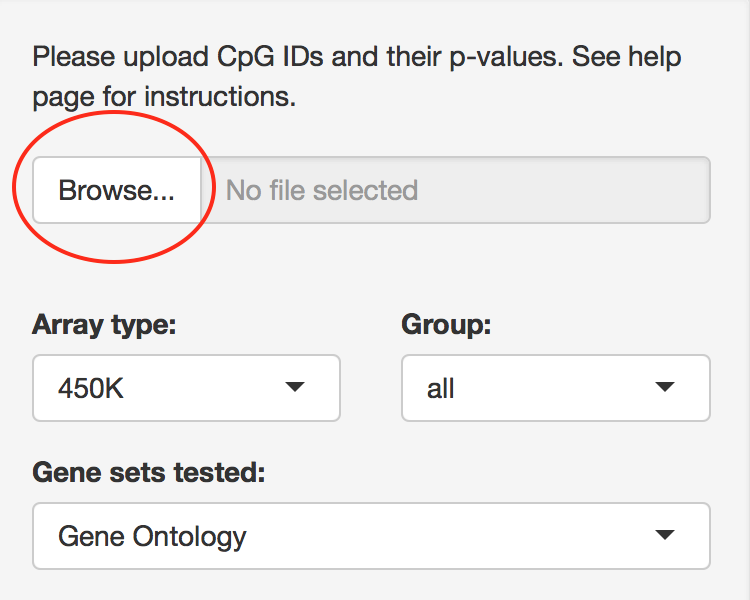

Users are expected to upload a txt file with 1st column CpG IDs, and 2nd column p-values correspond to the CpGs. For example:

cg13869341 0.307766  
cg14008030 0.257672  
cg12045430 0.552322  
cg20826792 0.056383  
cg00381604 0.468549  
cg20253340 0.483770  
cg21870274 0.812402  
…  
…  
…  
cg21106100 0.079276  
cg08265308 0.748265  
cg14273923 0.553923

Files should be no more than 100MB. Please check [**cpg_file_example.txt**](https://github.com/reese3928/methylGO-RShiny-app/raw/master/cpy_file_example.txt) for a toy dataset on Illumina 450 K Beadchip.

### Step 2

Choose array type and group.

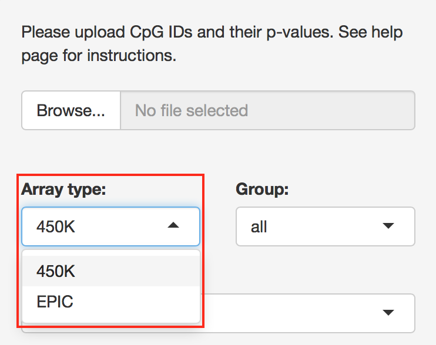

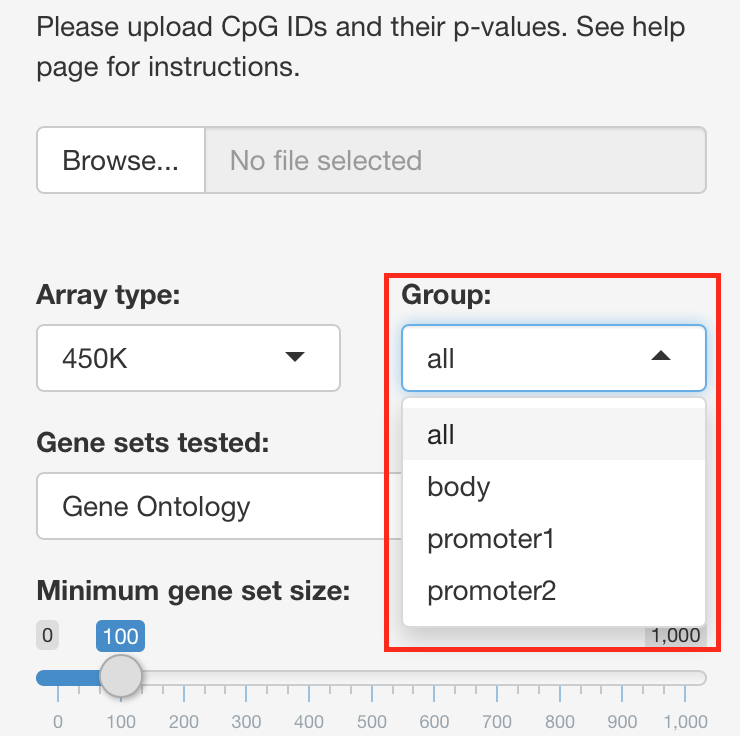

Array type:  
`450K`: Illumina 450 K Beadchip  
`EPIC`: Illumina EPIC Beadchip

Group:  
Group is the type of CpG to be considered in methylRRA or methylglm. By default, group is `all`, which means all CpGs are considered regardless of their gene group. If group is `body`, only CpGs on gene body will be considered. If group is `promoter1` or `promoter2`, only CpGs on promoters will be considered. Based on the annotation in IlluminaHumanMethylation450kanno.ilmn12.hg19 and IlluminaHumanMethylationEPICanno.ilm10b4.hg19, `body`, `promoter1` and `promoter2` are defined as:  
`body`: CpGs whose gene group correspond to “Body” or “1stExon”  
`promoter1`: CpGs whose gene group correspond to “TSS1500” or “TSS200”  
`promoter2`: CpGs whose gene group correspond to “TSS1500”, “TSS200”, “1stExon”, or “5’UTR”

### Step 3

Select gene sets to test.

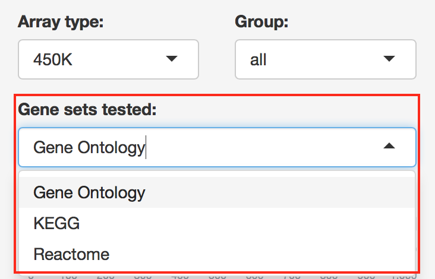

`Gene Ontology`: http://www.geneontology.org  
`KEGG` (Kyoto Encyclopedia of Genes and Genomes): https://www.genome.jp/kegg/  
`Reactome`: https://reactome.org

### Step 4

Select gene set sizes.

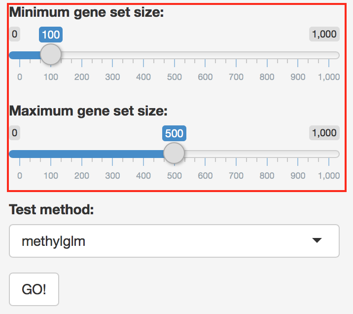

Gene sets outsize this range will not be tested.

### Step 5

Select gene set testing method.

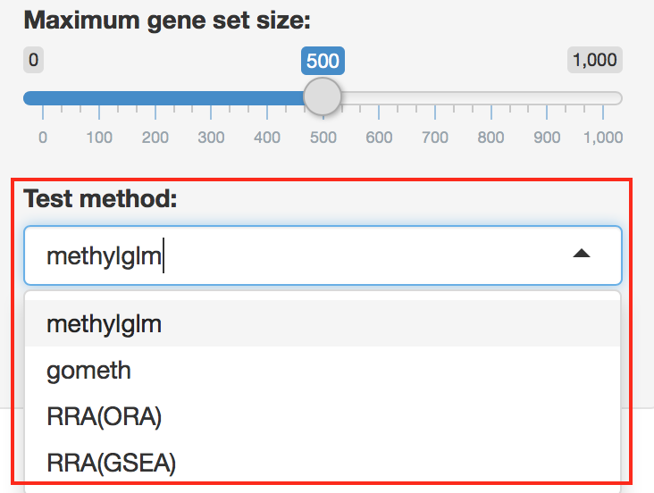

Check [this page](https://bioconductor.org/packages/devel/bioc/vignettes/methylGSA/inst/doc/methylGSA-vignette.html) for a description of methods.

### Step 6

Hit “GO!”.

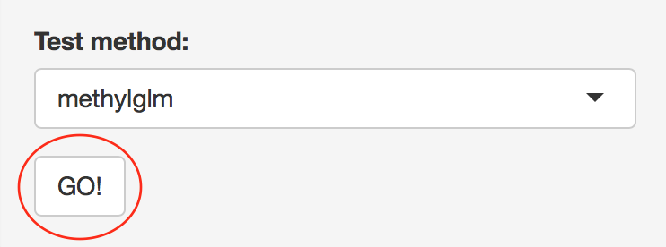

Gene set testing is running in the background. Depending on the number of gene sets tested, it may take several seconds to several minutes. Once it is done, the result is going to show up on the right hand panel.

### Interpreting the results

Hit “Download as csv” or “Download as txt” to save the results table to a csv or txt file:

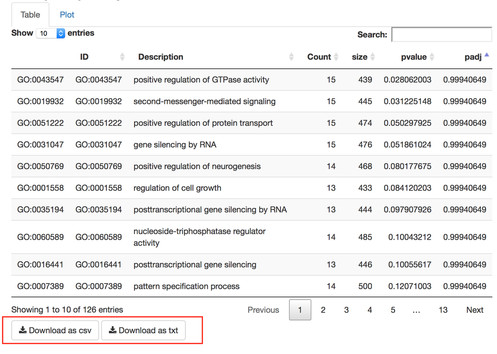

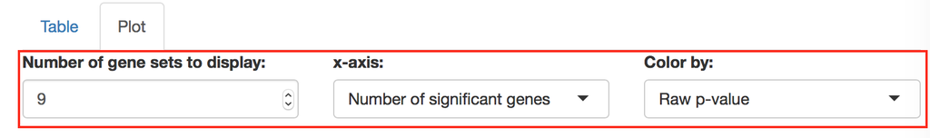

`Number of gene sets to display`: The number of genes sets to display on the plot.  
`x-axis`: Either the number of significant genes in each gene set or the total number of genes. The number of significant genes is not available for methylglm and methylRRA(GSEA) because they are FCS methods.  
`Color by`: Color the barplot by either raw p-value or adjusted p-value.

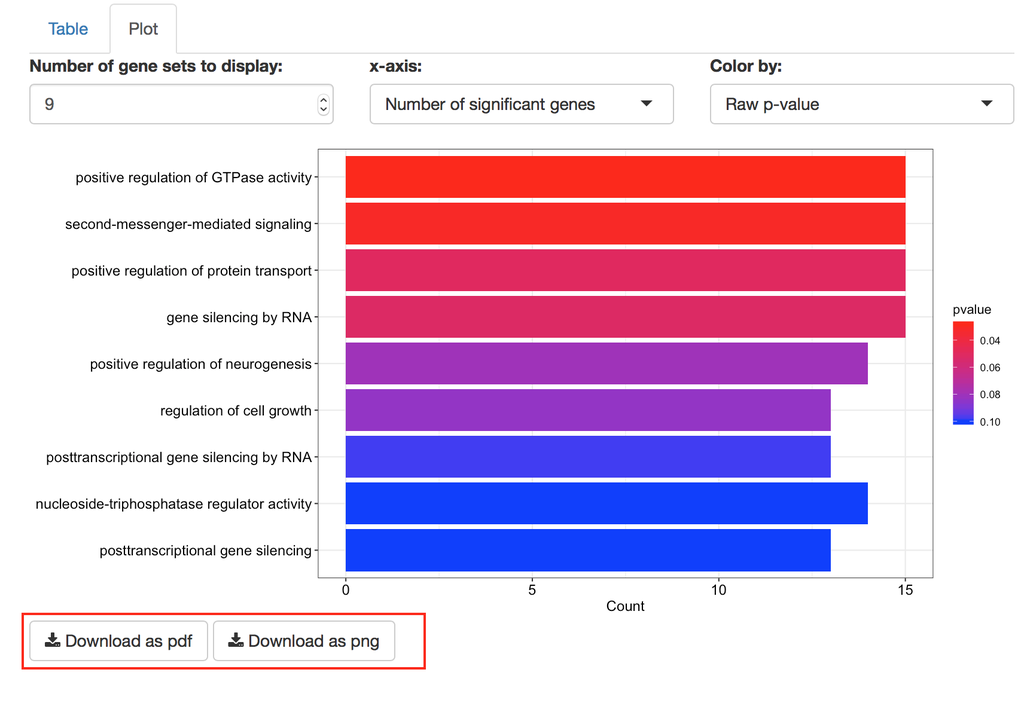